# Trade&Ahead - Problem Statement

## Data preprocessing

```python
# Check for duplicate values
duplicate_count = df.duplicated().sum()

# Identify potential outliers using the IQR method
Q1 = df[numerical_cols].quantile(0.25)
Q3 = df[numerical_cols].quantile(0.75)
IQR = Q3 - Q1

# Define outlier boundaries
lower_bound = Q1 - 1.5 * IQR
upper_bound = Q3 + 1.5 * IQR

# Count outliers for each numerial column
outliers = ((df[numerical_cols] < lower_bound) | (df[numerical_cols] > upper_bound)).sum()

duplicate_count, outliers
```

```
(0,
 Current Price                   22
 Price Change                    23
 Volatility                      20
 ROE                             39
 Cash Ratio                      16
 Net Cash Flow                   76
 Net Income                      57
 Earnings Per Share              39
 Estimated Shares Outstanding    35
 P/E Ratio                       41
 P/B Ratio                       30
 dtype: int64)
```

Obseervations

-- No Duplicate Rows – The dataset does not have any duplicate records.

-- Outliers Detected – Several financial indicators have a significant number of outliers:

- Net Cash Flow (76 outliers) and Net Income (57 outliers) have the most extreme values.
- ROE, Earnings Per Share, and P/E Ratio also contain many outliers. This is expected in financial data, as some companies have extremely high or low financial metrics.

# Outlier Detection & Treatment

```python
from scipy.stats.mstats import winsorize
from sklearn.preprocessing import StandardScaler

# Apply winsorization (capping outliers at 5th and 95th percentiles)
df_winsorized = df.copy()
for col in numerical_cols:
    df_winsorized[col] = winsorize(df[col], limits=[0.05, 0.05])
# Standardize the numerical columns for clustering
scaler = StandardScaler()
df_scaled = df_winsorized.copy()
df_scaled[numerical_cols] = scaler.fit_transform(df_winsorized[numerical_cols])

# Display the transformed data
df_scaled.head()
```

|  | Ticker Symbol | Security | GICS Sector | GICS Sub Industry | Current Price | Price Change | Volatility | ROE | Cash Ratio | Net Cash Flow | Net Income | Earnings Per Share | Estimated Shares Outstanding | P/E Ratio | P/B Ratio |
| --- | --- | --- | --- | --- | --- | --- | --- | --- | --- | --- | --- | --- | --- | --- | --- |
| 0 | AAL | American Airlines Group | Industrials | Airlines | -0.650258 | 0.592612 | 0.427781 | 2.912846 | -0.201175 | -0.844527 | 2.917364 | 2.232794 | 0.422851 | -0.837307 | -1.007119 |
| 1 | ABBV | AbbVie | Health Care | Pharmaceuticals | -0.274062 | 0.422717 | 1.536788 | 2.776416 | 0.265103 | 0.074986 | 1.846211 | 0.006802 | 2.577687 | -0.449873 | -1.002439 |
| 2 | ABT | Abbott Laboratories | Health Care | Health Care Equipment | -0.593238 | 0.725733 | -0.470099 | -0.197742 | 0.085766 | 1.320188 | 1.482433 | -0.064457 | 2.290503 | -0.603183 | 0.142625 |
| 3 | ADBE | Adobe Systems Inc | Information Technology | Application Software | 0.498819 | 0.999529 | -0.287631 | -0.525173 | 2.112282 | -0.334710 | -0.431541 | -0.634529 | 0.046579 | 1.970774 | 0.772146 |
| 4 | ADI | Analog Devices, Inc. | Information Technology | Semiconductors | -0.361374 | -0.617522 | 0.458219 | -0.388743 | 2.488891 | 0.445767 | -0.397571 | -0.956890 | 2.712391 | 2.775514 | 0.341873 |

Observations After Data Preprocessing:

- Outliers Handled – Winsorization successfully capped extreme values at the 5th and 95th percentiles.
- Feature Scaling Applied – All numerical features are now standardized (mean ≈ 0, variance ≈ 1), which is essential for clustering.

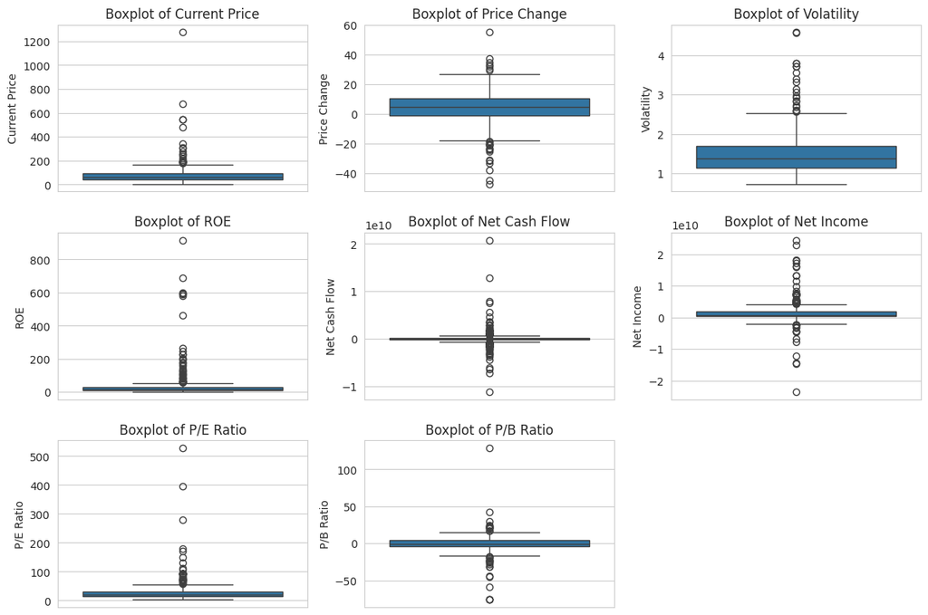

```python
import matplotlib.pyplot as plt
import seaborn as sns

# Set up the figure size
plt.figure(figsize=(12, 8))

# Boxplots for key numerical variables to visualize outliers
for i, col in enumerate(numeric_cols, 1):
    plt.subplot(3, 3, i)
    sns.boxplot(y=df[col])
    plt.title(f'Boxplot of {col}')

plt.tight_layout()
plt.show()
```